# E-news Express Project

#### **Bivariate Analysis**

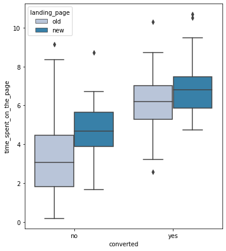

```python
'''Relationship between time spent on page to whether the user converted to a subscriber or not, comparing and
contrasting between the new and old landing page.'''

plt.figure(figsize=(6,7))
sns.boxplot(x = "converted", y = "time_spent_on_the_page", data = df, palette = 'PuBu', hue="landing_page")
```

**Observations:**

- The users that were converted spent significantly more time on both versions of the pages than those who were not with smaller ranges.
- Even with those who were not converted, the new landing page had a larger mean of time spent than the old landing page.
- The new landing page also had more positive outliers.

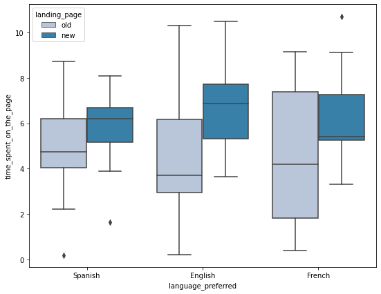

```python
# Relationship between time spent on the page to language preferred, comparing/contrasting the new/old landing page.

plt.figure(figsize=(9,7))
sns.boxplot(x = "language_preferred", y = "time_spent_on_the_page", data = df, palette = 'PuBu', hue="landing_page")
```

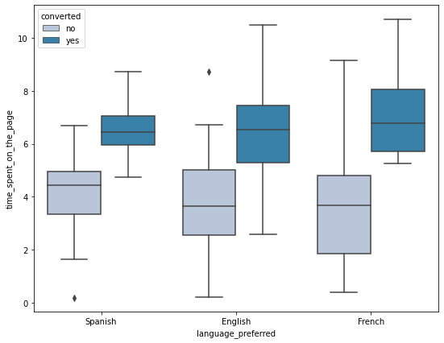

```python
# Relationship between time spent on the page to language preferred, comparing/contrasting converted/not converted.

plt.figure(figsize=(9,7))
sns.boxplot(x = "language_preferred", y = "time_spent_on_the_page", data = df, palette = 'PuBu', hue="converted")
```

### Question 2: Do the users spend more time on the new landing page than the old landing page?

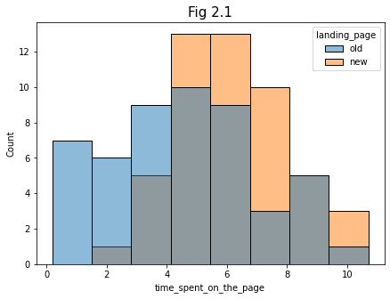

```python
plt.figure(figsize=(7,5))
a = sns.histplot(data = df, x = 'time_spent_on_the_page', hue="landing_page")
a.set_title("Fig 2.1", fontsize=15)
plt.show()

# Fig 2.1 Observations/Insights detailed after 2 sample T-test.
```

- By observing the above plot, we can say that overall people spent more times on the new page than the old age. Let's perform a hypothesis test to see if there are enough statistical evidence to support our observation.

#### Step 1: Define the null and alternate hypotheses:

$H_0:$ The mean time spent by the users on the new page is equal to the mean time spent by the users on the old page.

$H_a:$ The mean time spent by the users on the new page is greater than the mean time spent by the users on the old page.

Let $\mu_1$ and $\mu_2$ be the mean time spent by the users on the new and old page respectively.

Mathematically, the above formulated hypotheses can be written as:

$H_0: \mu_1 = \mu_2$

$H_a: \mu_1 > \mu_2$

#### Step 2: Select Appropriate Test:

This is a one-tailed test concerning two population means from two independent populations. As the population standard deviations are unknown, the two sample independent t-test will be the appropriate test for this problem.

#### Step 3: Decide the Significance Level:

As given in the problem statement, we select α = 0.05.

#### Step 4: Collect and prepare data:

```python
print('The mean time spent on the page for control group is', round(old['time_spent_on_the_page'].mean(),2))
print('The mean time spent on the page for treatment group is', round(old['time_spent_on_the_page'].std(),2))

print('The standard deviation of time spent on the page for control group is', round(new['time_spent_on_the_page'].mean(),2))
print('The standard deviation of time spent on the page for treatment group is', round(new['time_spent_on_the_page'].std(),2))
```

[output not shown]

As the sample standard deviations are different, the population standard deviations may be assumed to be different.

**Let's test whether the T-test assumptions are satisfied or not:**

- Continuous data - Yes, the time spent on the page is measured on a continuous scale.
- Normally distributed populations - Yes, from univariate analysis the distributions are close to normal.
- Independent populations - Our samples are from two different groups from two independent populations - the new landing page was the treatment group and the old landing page was the control group.
- Unequal population standard deviations - As the sample standard deviations are different, the population standard deviations may be assumed to be different.
- Random sampling from the population - Yes, it is given to us that the collected sample is random.

All conditions satisfied! We can use two sample T-test (one tailed) for this problem.

#### Step 5: Find the p-value:

```python
# find the p-value
test_stat, p_value = ttest_ind(new['time_spent_on_the_page'], old['time_spent_on_the_page'], equal_var = False, alternative = 'greater')
print('The p-value is', p_value)
```

```
The p-value is 0.0001392381225166549
```

#### Step 6: Compare the p-value with $\alpha$:

```python
# print the conclusion based on p-value
if p_value < 0.05:
    print(f'As the p-value {p_value} is less than the level of significance, we reject the null hypothesis.')
else:
    print(f'As the p-value {p_value} is greater than the level of significance, we fail to reject the null hypothesis.')
```

```
As the p-value 0.0001392381225166549 is less than the level of significance, we reject the null hypothesis.
```

#### Step 7: Draw inference:

- From Fig 2.1:
  - Initial impression is that the mean time spent on the new landing page is higher.
  - There are very few users that are in the 9-10 minute bracket for both versions of the landing page.
  - The old landing page has relatively more users spending between 0-4 minutes on it.
- From 2 sample T-test:

Since the p-value is less than the 5% significance level, we reject the null hypothesis. Hence, we have enough statistical evidence to say that the mean time spent by the users on the new page is greater than the mean time spent by the users on the old page.

### Question 3: Is the conversion rate (proportion of users who visit the landing page and get converted) for the new page greater than the conversion rate for the old page?

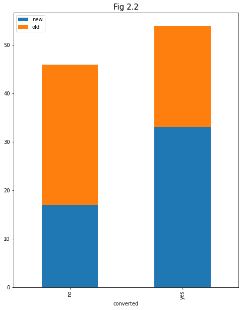

```python
plt.figure(figsize=(4,6))
a= pd.crosstab(df['converted'],df['landing_page']).plot(kind="bar", figsize=(8,10),
                 stacked=True)
a.set_title("Fig 2.2", fontsize=15)
plt.legend()
plt.show()

# Fig 2.2 Observations/Insights detailed after 2 proportion Z-test.
```

```python
df.groupby(by = ["converted"])['landing_page'].value_counts()
```

```
converted  landing_page
no         old             29
           new             17
yes        new             33
           old             21
Name: landing_page, dtype: int64
```

By observing the above plot, we can say that overall the number of users who get converted is more for the new page than the old page. Let's perform a hypothesis test to see if there is enough statistical evidence to say that the conversion rate for the new page is greater than the old page.

#### Step 1: Define the null and alternate hypotheses:

$H_0:$ The conversion rate for the new page is equal to the conversion rate for the old page.

$H_a:$ The conversion rate for the new page is greater than the conversion rate for the old page.

Let $p_1$ and $p_2$ be the conversion rate for the new and old page respectively.

Mathematically, the above formulated hypotheses can be written as:

$H_0: p_1 = p_2$

$H_a: p_1 > p_2$

#### Step 2: Select Appropriate Test:

This is a one-tailed test concerning two population proportions from two independent populations. Hence, the two proportion z-test will be the appropriate test for this problem.

#### Step 3: Decide the Significance Level:

As given in the problem statement, we select α = 0.05.

#### Step 4: Collect and prepare data:

```python
new_converted = df[df['group'] == 'treatment']['converted'].value_counts()['yes']
old_converted = df[df['group'] == 'control']['converted'].value_counts()['yes']
print('The numbers of converted users for the new and old pages are {0} and {1} respectively'.format(new_converted, old_converted))
n_control = df.group.value_counts()['control'] # number of users in the control group
n_treatment = df.group.value_counts()['treatment'] #number of users in the treatment group
print('The numbers of users served the new and old pages are {0} and {1} respectively'.format(n_control, n_treatment ))
```

```
The numbers of converted users for the new and old pages are 33 and 21 respectively
The numbers of users served the new and old pages are 50 and 50 respectively
```

**Let's test whether the Z-test assumptions are satisfied or not:**

- Binomally distributed population - Yes, a user is either converted or not converted.
- Random sampling from the population - Yes, it is given to us that the collected sample is random.
- Can this binmonial be approximated to normal distribution? - Yes. For binary, CLT works slower. Standard is to check if n*p and n*(1-p) are greater than or equal to 10, where n is sample size and p is sample proportion.
  - n *p_old = 50* (21/50) = 21 > 10 ✓
  - n *p_new = 50* (33/50) = 33 > 10 ✓
  - n *(1-p_old) = 50* ((50-21)/50) = 29 > 10 ✓
  - n *(1-p_old) = 50* ((50-33)/50) = 17 > 10 ✓

All conditions satisfied! We can use two proportion Z-test (one tailed) for this problem.

#### Step 5: Calculate the p-value:

```python
# set the counts of converted users for new and old landing pages respectively
converted = np.array([33, 21])

# set the sample sizes
sample_sizes = np.array([50, 50])

# find the p-value
test_stat, p_value = proportions_ztest(converted, sample_sizes, alternative = 'larger')
print('The p-value is', p_value)
```

```
The p-value is 0.008026308204056278
```

#### Step 6: Compare the p-value with $\alpha$:

```python
# print the conclusion based on p-value
if p_value < 0.05:
    print(f'As the p-value {p_value} is less than the level of significance, we reject the null hypothesis.')
else:
    print(f'As the p-value {p_value} is greater than the level of significance, we fail to reject the null hypothesis.')
```

```
As the p-value 0.008026308204056278 is less than the level of significance, we reject the null hypothesis.
```

#### Step 7: Draw inference:

- From Fig 2.2:
  - Initial impression is that the proportion of users who converted after viewing the landing page is higher for the new landing page versus the old one.
- From 2 proportion Z-Test:
  - Since the p-value is less than the 5% significance level, we reject the null hypothesis. Hence, we have enough statistical evidence to say that the conversion rate for the new page is greater than the conversion rate for the old page.

### Question 4: Does the converted status depend on the preferred language?

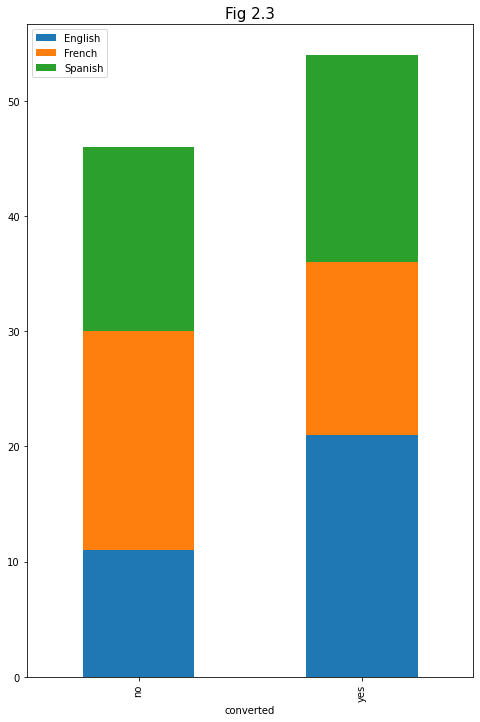

```python
# visual analysis of the dependency between conversion status and preferred langauge
plt.figure(figsize=(6,7))
a = pd.crosstab(df['converted'],df['language_preferred']).plot(kind="bar", figsize=(8,12),
                 stacked=True)
a.set_title("Fig 2.3", fontsize=15)
plt.legend()
plt.show()

# Fig 2.3 Observations/Insights detailed after Chi-Square Test for Independence.
```

The distribution of conversion status for English and French language users is not uniformly distributed. Let's perform the hypothesis test to check whether we have enough statistical evidence to say that the conversion status and preferred language are independent or not.

#### Step 1: Define the null and alternate hypotheses:

$H_0:$ The converted status is independent of the preferred language.

$H_a:$ The converted status is not independent of the preferred language.

#### Step 2: Select Appropriate test:

This is a problem of Chi-square test of independence, concerning the two independent categorical variables, converted status and preferred language.

#### Step 3: Decide the Significance Level:

As given in the problem statement, we select α = 0.05.

#### Step 4: Collect and prepare data:

```python
# create the contingency table showing the distribution of language against conversion status

Q4 = pd.crosstab(df['converted'], df['language_preferred'])
Q4
```

| language_preferred converted | English | French | Spanish |
| --- | --- | --- | --- |
| no | 11 | 19 | 16 |
| yes | 21 | 15 | 18 |

**Let's test whether Chi-Square-test for independence assumptions are satisfied:**

- Categorical variables - Yes
- Expected value of the number of sample observations in each level of the variable is at least 5 - Yes, the number of observations in each level is greater than 5.
- Random sampling from the population - Yes, it is given to us that the collected sample is random.

All conditions satisfied! We can use a chi-squared test of independence for this problem.

#### Step 5: Calculate the p-value:

```python
# find the p-value

chi2, p_value, dof, exp_freq = chi2_contingency(Q4)
print('The p-value is', p_value)
```

```
The p-value is 0.21298887487543447
```

#### Step 6: Compare the p-value with $\alpha$:

```python
# print the conclusion based on p-value
if p_value < 0.05:
    print(f'As the p-value {p_value} is less than the level of significance, we reject the null hypothesis.')
else:
    print(f'As the p-value {p_value} is greater than the level of significance, we fail to reject the null hypothesis.')
```

```
As the p-value 0.21298887487543447 is greater than the level of significance, we fail to reject the null hypothesis.
```

#### Step 7: Draw inference:

- From Fig 2.3:
  - Initial impression is that English has the highest proportion of users converted, and French has the lowest.
- From Chi-Square Test for Independence:
  - Since the p-value is greater than the 5% significance level, we fail to reject the null hypothesis. Hence, we do not have enough statistical evidence to say that the converted status depends on the preferred language.

### Question 5: Is the mean time spent on the new page the same for the different language users?

```python
df.groupby('language_preferred')['time_spent_on_the_page'].mean()
```

```
language_preferred
English    5.559063
French     5.253235
Spanish    5.331765
Name: time_spent_on_the_page, dtype: float64
```

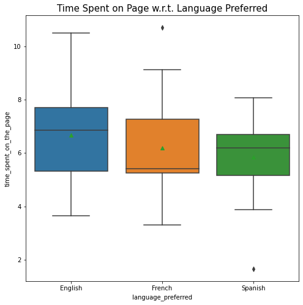

```python
# Use dataframe we created above only for new landing page

plt.figure(figsize=(8,8))
a = sns.boxplot(x = 'language_preferred', y = 'time_spent_on_the_page', showmeans = True, data = new)
a.set_title("Time Spent on Page w.r.t. Language Preferred", fontsize=15)
plt.show()
```

The mean time spent on the new page by English users is a bit higher than the mean time spent by French and Spanish users, but we need to test if this difference is statistically significant or not.

#### Step 1: Define the null and alternate hypotheses:

$H_0:$ The mean times spent on the new page by English, French, and Spanish users are equal (μ_English = μ_Spanish = μ_French)

$H_a:$ At least one of the mean times spent on the new page by English, French, and Spanish users is unequal.

#### Step 2: Select Appropriate test:

This is a problem, concerning three population means. One-way ANOVA could be the appropriate test here provided normality and equality of variance assumptions are verified.

- For testing of normality, Shapiro-Wilk’s test is applied to the response variable.
- For equality of variance, Levene test is applied to the response variable.

#### Shapiro-Wilk’s test

We will test the null hypothesis

> $H_0:$ Time spent on the new page follows a normal distribution

against the alternative hypothesis

> $H_a:$ Time spent on the new page does not follow a normal distribution

```python
# Assumption 1: Normality (Shapiro-Wilk's Test applied to response variable)

# find the p-value
w, p_value = stats.shapiro(new['time_spent_on_the_page'])
print('The p-value is', p_value)
```

```
The p-value is 0.8040016293525696
```

Since p-value of the test is very large than the 5% significance level, we fail to reject the null hypothesis that the response follows the normal distribution. Thus, we do not have enough statistical evidence to say that the time spent on the page doesn't follow a normal distribution.

#### Levene's test

We will test the null hypothesis

> $H_0$: All the population variances are equal

against the alternative hypothesis

> $H_a$: At least one variance is different from the rest

```python
# Assumption 2: Homogeneity of Variance (Levene's Test applied to response variable)

# find the p-value
statistic, p_value = levene( new['time_spent_on_the_page'][new['language_preferred']=="English"],
                             new['time_spent_on_the_page'][new['language_preferred']=="Spanish"],
                             new['time_spent_on_the_page'][new['language_preferred']=="French"])
print('The p-value is', p_value)
```

```
The p-value is 0.46711357711340173
```

Since the p-value is large than the 5% significance level, we fail to reject the null hypothesis of homogeneity of variances. Thus, we do not have enough statistical evidence to say that the variances are not all equal.

**Check if assumptions are satisfied:**

- Normal distribution for populations - Yes, the normality assumption is verified using the Shapiro-Wilk’s test.
- Samples independent and random - Yes, it is given to us that the collected sample is a simple random sample.
- Population variances are equal - Yes, the homogeneity of variance assumption is verified using the Levene's test.

#### Step 3: Decide the Significance Level:

As given in the problem statement, we select α = 0.05.

#### Step 4: Collect and prepare data:

```python
English = new[new['language_preferred']=="English"]['time_spent_on_the_page']
French = new[new['language_preferred']=="French"]['time_spent_on_the_page']
Spanish = new[new['language_preferred']=="Spanish"]['time_spent_on_the_page']
```

#### Step 5: Calculate the p-value:

```python
# perform one-way anova test

test_stat, p_value = f_oneway(English, French, Spanish)
print('The p-value is ', p_value)
```

```
The p-value is  0.43204138694325955
```

#### Step 6: Compare the p-value with $\alpha$:

```python
# print the conclusion based on p-value
if p_value < 0.05:
    print(f'As the p-value {p_value} is less than the level of significance, we reject the null hypothesis.')
else:
    print(f'As the p-value {p_value} is greater than the level of significance, we fail to reject the null hypothesis.')
```

```
As the p-value 0.43204138694325955 is greater than the level of significance, we fail to reject the null hypothesis.
```

#### Step 7: Draw inference:

For a cross check, a multiple pairwise comparison tests which (if any) means are different from the rest.

```python
# perform multiple pairwise comparison (Tukey HSD)
m_comp = pairwise_tukeyhsd(endog = new['time_spent_on_the_page'], groups = new['language_preferred'], alpha = 0.05)
print(m_comp)
```

```
 Multiple Comparison of Means - Tukey HSD, FWER=0.05
=====================================================
 group1  group2 meandiff p-adj   lower  upper  reject
-----------------------------------------------------
English  French  -0.4673 0.7259 -2.0035  1.069  False
English Spanish  -0.8285  0.401 -2.3647 0.7078  False
 French Spanish  -0.3612  0.816  -1.874 1.1516  False
-----------------------------------------------------
```

**Observations:**

- The p-adj column refers to the p-value. In this case, they are all above the significance level, meaning we must fail to reject the null hypothesis that all the means for time spent for different languages are the same.
- Thus, we can say that the mean time spent on the page for different languages are all similar.

### Business Recommendations

- Overall, Enews Express made a good decision updating the landing page for their online news portal.
- Our sample of users and further hypotheses we conducted leads us to the conclusion that users will be more likely to convert to subscribers of the portal with the new landing page.
- Further recommendations to expand their business include:
  - Expand the languages offered to view the online news portal.
  - Make the Subscribe button easy to find on the home page.
  - Once subscribed, to keep users subscribed, provide incentives like newsletters, discounts for holidays, etc.
  - For the smartphone/mobile version of the news portal, be sure to adjust the design for the screen size.
  - Include hyperlinks within a certain story if it references other articles/newsletters.